# Deconvolution and nonnegative matrix factorization

## Cell type proportions

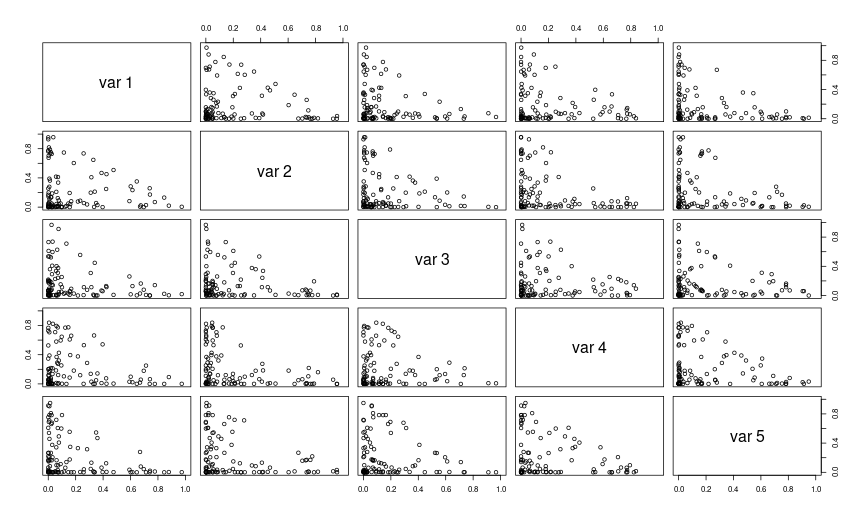

```r
pairs(w, xlim=c(0,1), ylim=c(0,1))
```

## Total expression per sample

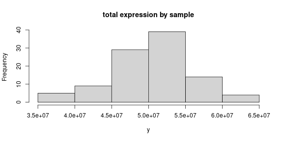

```r
# y[i] is total reads for sample i
y <- rnorm(num_samples, mean=mean_total_expression, sd=sd_total_expression)

hist(y, main='total expression by sample')
```

## Simulate expression

1. scale mean expression based on total expression level
2. matrix multiply mean scaled levels by proportions (x * w)
3. actual expression levels are Poisson (TODO: make overdispersed)

```r
# Z[i,j] is read counts of sample i for gene j

# this will have mean_Z[i,j] = (sum_k w[i,k] x[k,j])
mean_Z <- (w %*% x)
# but we want total sequencing to be y[i] so...
mean_Z <- y * mean_Z / rowSums(mean_Z)
stopifnot(all(abs(y - rowSums(mean_Z)) < 1e-8))
Z <- rpois(length(mean_Z), lambda=mean_Z)
dim(Z) <- dim(mean_Z)
```

## Visualize normalized expression levels

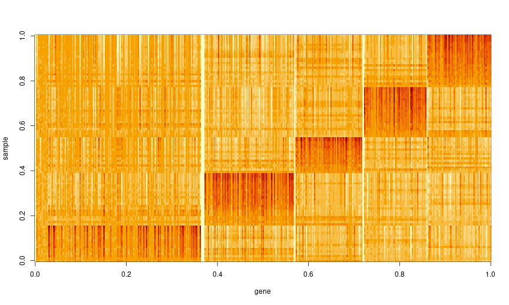

```r
w_ord <- order(apply(w, 1, which.max), rowMaxs(w)) # order samples by proportion
Znorm <- Z / pmax(100, colMeans(Z)[col(Z)])
Znorm[!is.finite(Znorm)] <- 1
Znorm <- Znorm / rowMeans(Znorm)
image(t(Znorm[w_ord,x_ord]), xlab='gene', ylab='sample')
```

# Exercise

Suppose instead that $Z_{ij}$ is number of individuals of plant species $j$ in a quadrat at spatial location $i$, sampled in a transect across an environmental transition (e.g., up the Cascades).

Applying the same method, what are $x_{ik}$ and $w_{kj}$?

# Fit the model

```r
fit_sim1 <- optimizing(nmf_model,
                data=list(N=num_samples,
                          L=num_genes,
                          K=num_cell_types,
                          Z=Z),
                seed=125)
```

## The results!

Here’s the correlation matrix between inferred and true cell type proportions, $w$:

```r
opt_w <- fit_sim1$par[grepl("^w", names(fit_sim1$par))]
dim(opt_w) <- c(num_samples, num_cell_types)
cor(w, opt_w)
```

```
##            [,1]        [,2]        [,3]       [,4]       [,5]
## [1,] -0.3650149 -0.46800709  0.01241053  0.9883737 -0.7094076
## [2,] -0.4649357 -0.68112510  0.98500504 -0.2470444  0.4452517
## [3,]  0.1109181  0.69846265 -0.23809420 -0.1459216 -0.2516304
## [4,]  0.9617917  0.09698111 -0.43534224 -0.2610371 -0.2615736
## [5,] -0.1944083  0.45636680 -0.39478167 -0.2909646  0.6459502
```

## HOWever…

```r
fit_sim2 <- optimizing(nmf_model,
                data=list(N=num_samples,
                          L=num_genes,
                          K=num_cell_types,
                          Z=Z),
                seed=127)
```

## The results, again?

```r
opt_w <- fit_sim2$par[grepl("^w", names(fit_sim2$par))]
dim(opt_w) <- c(num_samples, num_cell_types)
cor(w, opt_w)
```

```
##            [,1]       [,2]       [,3]        [,4]        [,5]
## [1,] -0.2172411 -0.4078729 -0.6425219  0.01929908  0.94837974
## [2,]  0.1665108 -0.4485661 -0.6618148  0.94222156 -0.34250032
## [3,] -0.4188313  0.1169822  0.3839463 -0.04175999 -0.02495652
## [4,] -0.5288389  0.9550957  0.4536915 -0.38017185 -0.05111174
## [5,]  0.8598106 -0.1703489  0.5119214 -0.56631736 -0.45240318
```

## Goodness-of-fit

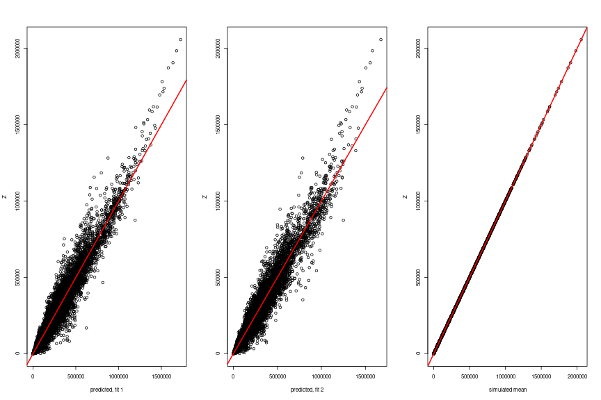

## What’s going on?

```
optimizing                package:rstan                R Documentation

Obtain a point estimate by maximizing the joint posterior

Description:

     Obtain a point estimate by maximizing the joint posterior from the
     model defined by class ‘stanmodel’.

Usage:

     ## S4 method for signature 'stanmodel'
     optimizing(object, data = list(),
         seed = sample.int(.Machine$integer.max, 1), init = 'random',
         check_data = TRUE, sample_file = NULL,
         algorithm = c("LBFGS", "BFGS", "Newton"),
         verbose = FALSE, hessian = FALSE, as_vector = TRUE,
         draws = 0, constrained = TRUE, importance_resampling = FALSE, ...)

Arguments:

  object: An object of class ‘stanmodel’.

    data: A named ‘list’ or ‘environment’ providing the data for the
          model or a character vector for all the names of objects used
          as data.  See the *Passing data to Stan* section in ‘stan’.

    seed: The seed for random number generation. The default is
          generated from 1 to the maximum integer supported by R on the
          machine. Even if multiple chains are used, only one seed is
          needed, with other chains having seeds derived from that of
          the first chain to avoid dependent samples.  When a seed is
          specified by a number, ‘as.integer’ will be applied to it.
          If ‘as.integer’ produces ‘NA’, the seed is generated
          randomly.  The seed can also be specified as a character
          string of digits, such as ‘"12345"’, which is converted to
          integer.

    init: Initial values specification. See the detailed documentation
          for the ‘init’ argument in ‘stan’ with one exception. If
          specifying inits using a list then only a single named list
          of values should be provided.  For example, to initialize a
          parameter ‘alpha’ to ‘value1’ and ‘beta’ to ‘value2’ you can
          specify ‘list(alpha = value1, beta = value2)’.
```

## MCMC?

Too slow.

# NMF?

## `?nmf in r`

Well, there’s the [RcppML package](https://github.com/zdebruine/RcppML)?

```
install.packages('RcppML')
```

It’s got great documentation: that’s very reasurring!

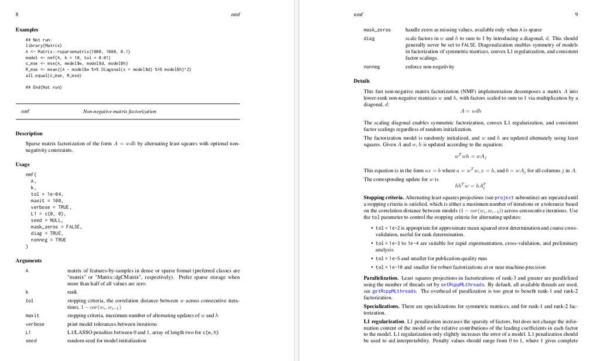

```r
library(RcppML)
nmfZ <- nmf(Z, k=5)
```

```
##
## iter |      tol
## ---------------
##    1 | 8.51e-01
##    2 | 5.63e-02
##    3 | 8.28e-03
##    4 | 2.21e-03
##    5 | 9.61e-04
##    6 | 5.98e-04
##    7 | 4.40e-04
##    8 | 3.41e-04
##    9 | 2.69e-04
##   10 | 2.09e-04
##   11 | 1.61e-04
##   12 | 1.22e-04
##   13 | 9.31e-05
```

It works just as well - maybe a bit better?

```r
cor(nmfZ$w, w)
```

```
##            [,1]        [,2]       [,3]       [,4]       [,5]
## [1,] -0.2330194  0.97158136 -0.2830714 -0.4389302 -0.1194442
## [2,] -0.3175350 -0.34415247  0.1480907  0.9398846 -0.3668171
## [3,] -0.1844490 -0.58272410 -0.3638424  0.2049184  0.8452016
## [4,]  0.9860517 -0.06099348 -0.1947311 -0.2987144 -0.3999482
## [5,] -0.4224679 -0.34921183  0.7949414 -0.3476999  0.4241365
```

# Takeaways

1. There are many possible ways to obtain low-dimensional approximations: think about what you want.
2. Often we want to impose conditions to improve *interpretability*.
3. Unfortunately, these often suffer from nonidentifiability. (Why? Find $x$ and $y$ to solve $24 = xy$.)
4. With a lot of data and a complex model, MCMC can be way too slow.
5. Optimization of “non-convex” problems can be hard, and require special approaches.
6. Careful documentation is a sign of reliable software.
7. Check your results, with simulation!